# Relatório Hugo Cobra (INTO 2016)

Felipe Figueiredo

June 21, 2016

# Metodologia utilizada

A análise descritiva foi apresentada na forma de tabelas os dados observados, expressos pela média, desvio padrão, mediana, amplitude interquartílica (AIQ), mínimo e máximo para dados numéricos (quantitativos) e pela frequência (n) e percentual (%) para dados categóricos (qualitativos). Ao longo do texto, as variáveis normais foram sumarizadas como média +/- desvio padrão (DP), e as variáveis não normais como mediana +/- AIQ.

Foi aplicado o teste de normalidade de Shapiro-Wilks nas variáveis numéricas. A comparação das variáveis basais e finais foi feita com o teste t para variáveis normalmente distribuídas, e com o teste de Mann-Whitney para variáveis que tiveram a hipótese de normalidade rejeitada. Para variáveis normais, foi aplicada a correlação de Pearson, e para variáveis não normais, a correlação não paramétrica de Spearman.

A fim de investigar possíveis fatores de risco para o desfecho, foram ajustados modelos de regressão logística, tendo o desfecho como variável resposta. A significância global de cada um destes modelos foi avaliada pelo teste de Wald.

Em todas as análises, foi adotada a significância de 5%. As análises estatísticas foram feitas utilizando o software estatístico R, versão 3.3.0 (https://www.R-project.org).

# Resultados

## Tabelas descritivas

### Dados numéricos

|  | Média | DP | Mediana | AIQ |
| --- | --- | --- | --- | --- |
| **Idade** | 66.19 | 9.25 | 67 | 12 |
| **IMC** | 30.05 | 5.45 | 29.68 | 7 |
| **Albumina** | 3.63 | 0.66 | 3.6 | 0.75 |
| **Globulina** | 2.67 | 0.86 | 2.73 | 1.08 |
| **Tempo** | 88.69 | 20.9 | 87 | 27 |

A média (DP) das idades é 66.19 (9.25)

### Dados categóricos

| ATB | Sexo | Diagnóstico | DM | ASA | Desfecho |
| --- | --- | --- | --- | --- | --- |
| N:156 | F:231 | AR : 50 | N:224 | I : 16 | N:279 |
| S:128 | M: 53 | OA :230 | S: 60 | II :260 | S: 5 |
| NA | NA | ON : 2 | NA | III : 6 | NA |
| NA | NA | Outros: 2 | NA | NA’s: 2 | NA |

## Tabelas de Contingência

As tabelas de contingência a seguir, associam duas variáveis categóricas. Nas estão representadas as categorias do Desfecho (S = infeccção e N = não infeccão). OS p-valores correspondem ao teste de Fisher.

### Sexo por tratamento

|  | N | S |
| --- | --- | --- |
| **F** | 46.1 | 35.2 |
| **M** | 8.8 | 9.9 |

P-valor: 0.2235331

### Diabete por tratamento

|  | N | S |
| --- | --- | --- |
| **N** | 43 | 35.9 |
| **S** | 12 | 9.2 |

P-valor: 0.7725722

### Diagnostico por tratamento

|  | N | S |
| --- | --- | --- |
| **AR** | 8.8 | 8.8 |
| **OA** | 45.4 | 35.6 |
| **ON** | 0 | 0.7 |
| **Outros** | 0.7 | 0 |

P-valor: 0.210475

### ASA por Tratamento

|  | N | S |
| --- | --- | --- |
| **I** | 2.8 | 2.8 |
| **II** | 50.4 | 41.8 |
| **III** | 1.8 | 0.4 |

P-valor: 0.3976111

### Desfecho por Tratamento

|  | N | S |
| --- | --- | --- |
| **N** | 53.9 | 1.1 |
| **S** | 44.4 | 0.7 |

P-valor: 1

### Desfecho por ASA

|  | N | S |
| --- | --- | --- |
| **I** | 5.7 | 0 |
| **II** | 90.8 | 1.4 |
| **III** | 2.1 | 0 |

P-valor: 1

## Gráficos

### Dados numéricos

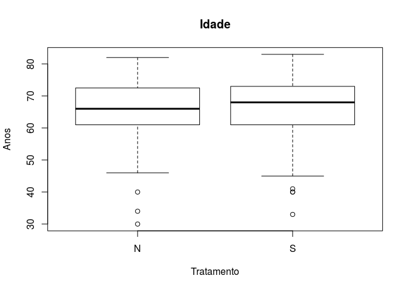

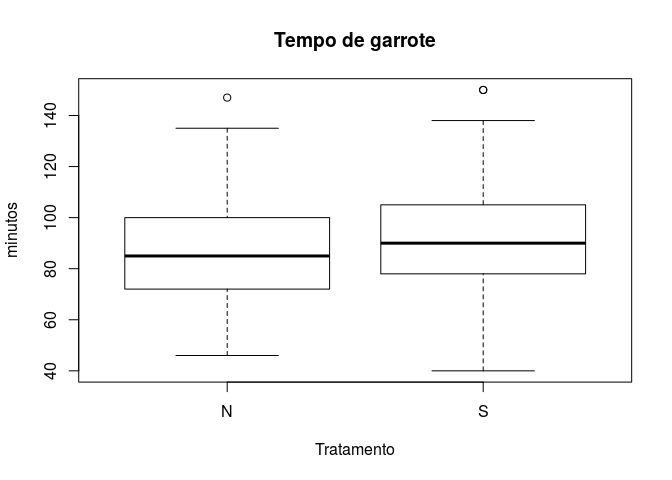

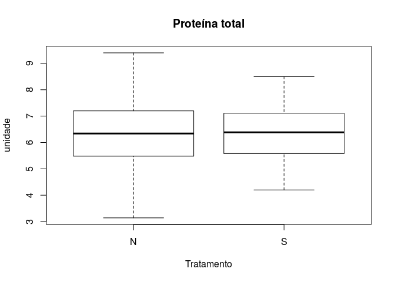

### Dados categóricos

#### Desfecho por tratamento

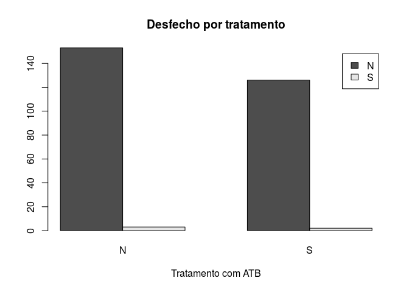

#### Outros dados, por tratamento

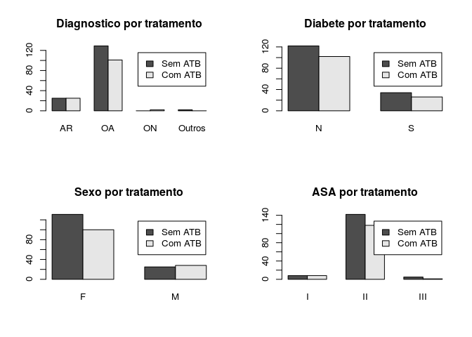

## Análise de Regressão

### Modelos de uma variável

Foi feita uma análise de regressão logística, tomando como variável resposta o Desfecho (binário). Cada modelo de regressão logística simples considerou como variável preditora cada um dos seguintes dados:

- Tratamento
- Diabete
- Sexo
- Idade
- IMC
- Proteína total
- Diagnóstico

A **única** análise que retornou diferença significativa foi levando em conta o sexo.

O log da razão de chances de se selecionar um homem ao invés de uma mulher na amostra é: 1.9271641. Usando a exponencial para cancelar o lograritmo, podemos interpretar este resultado como: os homens tem uma chance 6.87 maior que as mulheres de ter o desfecho [infecção na cirurgia, etc].

**Sugestão de redação**: *Dos fatores de risco analisados neste estudo, o único identificado como significativo foi o sexo. Nesta amostra, os homens têm uma chance 6.87 maior que as mulheres de desenvolver a condição…*

A seguir, as tabelas de resultados das regressões logísticas analisadas.

```
##
## Call:
## glm(formula = Desfecho ~ ATB, family = binomial(link = "logit"))
##
## Deviance Residuals:
##     Min       1Q   Median       3Q      Max
## -0.1971  -0.1971  -0.1971  -0.1775   2.8840
##
## Coefficients:
##             Estimate Std. Error z value Pr(>|z|)
## (Intercept)  -3.9318     0.5830  -6.744 1.54e-11 ***
## ATBS         -0.2113     0.9208  -0.229    0.818
## ---
## Signif. codes:  0 '***' 0.001 '**' 0.01 '*' 0.05 '.' 0.1 ' ' 1
##
## (Dispersion parameter for binomial family taken to be 1)
##
##     Null deviance: 50.307  on 283  degrees of freedom
## Residual deviance: 50.254  on 282  degrees of freedom
## AIC: 54.254
##
## Number of Fisher Scoring iterations: 7
```

```
##
## Call:
## glm(formula = Desfecho ~ DM, family = binomial(link = "logit"))
##
## Deviance Residuals:
##     Min       1Q   Median       3Q      Max
## -0.2125  -0.2125  -0.2125  -0.2125   2.7576
##
## Coefficients:
##              Estimate Std. Error z value Pr(>|z|)
## (Intercept)   -3.7796     0.4523  -8.357   <2e-16 ***
## DMS          -16.7864  2288.9810  -0.007    0.994
## ---
## Signif. codes:  0 '***' 0.001 '**' 0.01 '*' 0.05 '.' 0.1 ' ' 1
##
## (Dispersion parameter for binomial family taken to be 1)
##
##     Null deviance: 50.307  on 283  degrees of freedom
## Residual deviance: 47.910  on 282  degrees of freedom
## AIC: 51.91
##
## Number of Fisher Scoring iterations: 19
```

```
##
## Call:
## glm(formula = Desfecho ~ Sexo, family = binomial(link = "logit"))
##
## Deviance Residuals:
##     Min       1Q   Median       3Q      Max
## -0.3414  -0.1319  -0.1319  -0.1319   3.0820
##
## Coefficients:
##             Estimate Std. Error z value Pr(>|z|)
## (Intercept)  -4.7406     0.7102  -6.675 2.47e-11 ***
## SexoM         1.9272     0.9261   2.081   0.0374 *
## ---
## Signif. codes:  0 '***' 0.001 '**' 0.01 '*' 0.05 '.' 0.1 ' ' 1
##
## (Dispersion parameter for binomial family taken to be 1)
##
##     Null deviance: 50.307  on 283  degrees of freedom
## Residual deviance: 46.037  on 282  degrees of freedom
## AIC: 50.037
##
## Number of Fisher Scoring iterations: 7
```

```
##
## Call:
## glm(formula = Desfecho ~ Idade, family = binomial(link = "logit"))
##
## Deviance Residuals:
##     Min       1Q   Median       3Q      Max
## -0.3160  -0.1998  -0.1827  -0.1671   2.9757
##
## Coefficients:
##             Estimate Std. Error z value Pr(>|z|)
## (Intercept) -2.06966    2.78453  -0.743    0.457
## Idade       -0.03007    0.04329  -0.695    0.487
##
## (Dispersion parameter for binomial family taken to be 1)
##
##     Null deviance: 50.307  on 283  degrees of freedom
## Residual deviance: 49.861  on 282  degrees of freedom
## AIC: 53.861
##
## Number of Fisher Scoring iterations: 7
```

```
##
## Call:
## glm(formula = Desfecho ~ IMC, family = binomial(link = "logit"))
##
## Deviance Residuals:
##     Min       1Q   Median       3Q      Max
## -0.2587  -0.2010  -0.1863  -0.1724   2.9647
##
## Coefficients:
##             Estimate Std. Error z value Pr(>|z|)
## (Intercept) -5.31048    2.55216  -2.081   0.0375 *
## IMC          0.04298    0.08024   0.536   0.5922
## ---
## Signif. codes:  0 '***' 0.001 '**' 0.01 '*' 0.05 '.' 0.1 ' ' 1
##
## (Dispersion parameter for binomial family taken to be 1)
##
##     Null deviance: 50.018  on 275  degrees of freedom
## Residual deviance: 49.737  on 274  degrees of freedom
##   (8 observations deleted due to missingness)
## AIC: 53.737
##
## Number of Fisher Scoring iterations: 7
```

```
##
## Call:
## glm(formula = Desfecho ~ ptn, family = binomial(link = "logit"))
##
## Deviance Residuals:
##      Min        1Q    Median        3Q       Max
## -0.26855  -0.14210  -0.11422  -0.09179   3.14577
##
## Coefficients:
##             Estimate Std. Error z value Pr(>|z|)
## (Intercept)  -1.6253     3.7617  -0.432    0.666
## ptn          -0.5348     0.6530  -0.819    0.413
##
## (Dispersion parameter for binomial family taken to be 1)
##
##     Null deviance: 23.297  on 249  degrees of freedom
## Residual deviance: 22.609  on 248  degrees of freedom
##   (34 observations deleted due to missingness)
## AIC: 26.609
##
## Number of Fisher Scoring iterations: 8
```

```
##
## Call:
## glm(formula = Desfecho ~ Diagnóstico, family = binomial(link = "logit"))
##
## Deviance Residuals:
##     Min       1Q   Median       3Q      Max
## -0.2857  -0.1620  -0.1620  -0.1620   2.9460
##
## Coefficients:
##                    Estimate Std. Error z value Pr(>|z|)
## (Intercept)         -3.1781     0.7217  -4.404 1.06e-05 ***
## DiagnósticoOA       -1.1483     0.9266  -1.239    0.215
## DiagnósticoON      -14.3880  2797.4420  -0.005    0.996
## DiagnósticoOutros  -14.3880  2797.4420  -0.005    0.996
## ---
## Signif. codes:  0 '***' 0.001 '**' 0.01 '*' 0.05 '.' 0.1 ' ' 1
##
## (Dispersion parameter for binomial family taken to be 1)
##
##     Null deviance: 50.307  on 283  degrees of freedom
## Residual deviance: 48.792  on 280  degrees of freedom
## AIC: 56.792
##
## Number of Fisher Scoring iterations: 16
```

### Modelo com todas as variáveis

Por fim, foi criado também um modelo logístico para o desfecho tendo como preditores **todas** as outras variáveis do estudo (resultado não mostrado). Neste modelo “saturado”, as combinações não resultaram em significância estatística das chances de uma categoria para outra.

Sugestão: este resultado pode ser omitido da redação sem perda de generalidade, e foi incluído apenas para compleição da análise.